# W3cubDocs

/Qt 6.9

# QComboBox Class

The QComboBox widget combines a button with a dropdown list. More...

| Header: | `#include <QComboBox>` |
| --- | --- |
| CMake: | `find_package(Qt6 REQUIRED COMPONENTS Widgets)` `target_link_libraries(mytarget PRIVATE Qt6::Widgets)` |
| qmake: | `QT += widgets` |
| Inherits: | QWidget |
| Inherited By: | QFontComboBox |

- [List of all members, including inherited members](https://doc.qt.io/qt-6.9/qcombobox-members.html)

## Public Types

| enum | **InsertPolicy** { NoInsert, InsertAtTop, InsertAtCurrent, InsertAtBottom, InsertAfterCurrent, …, InsertAlphabetically } |
| --- | --- |
| `(since 6.9)` enum class | **LabelDrawingMode** { UseStyle, UseDelegate } |
| enum | **SizeAdjustPolicy** { AdjustToContents, AdjustToContentsOnFirstShow, AdjustToMinimumContentsLengthWithIcon } |

## Properties

- **count** : const int
- **currentData** : const QVariant
- **currentIndex** : int
- **currentText** : QString
- **duplicatesEnabled** : bool
- **editable** : bool
- **frame** : bool
- **iconSize** : QSize
- **insertPolicy** : InsertPolicy
- `(since 6.9)` **labelDrawingMode** : LabelDrawingMode
- **maxCount** : int
- **maxVisibleItems** : int
- **minimumContentsLength** : int
- **modelColumn** : int
- **placeholderText** : QString
- **sizeAdjustPolicy** : SizeAdjustPolicy

## Public Functions

|  | **QComboBox**(QWidget **parent* = nullptr) |
| --- | --- |
| virtual | **~QComboBox**() |
| void | **addItem**(const QString &*text*, const QVariant &*userData* = QVariant()) |
| void | **addItem**(const QIcon &*icon*, const QString &*text*, const QVariant &*userData* = QVariant()) |
| void | **addItems**(const QStringList &*texts*) |
| QCompleter * | **completer**() const |
| int | **count**() const |
| QVariant | **currentData**(int *role* = Qt::UserRole) const |
| int | **currentIndex**() const |
| QString | **currentText**() const |
| bool | **duplicatesEnabled**() const |
| int | **findData**(const QVariant &*data*, int *role* = Qt::UserRole, Qt::MatchFlags *flags* = static_cast<Qt::MatchFlags>(Qt::MatchExactly\|Qt::MatchCaseSensitive)) const |
| int | **findText**(const QString &*text*, Qt::MatchFlags *flags* = Qt::MatchExactly\|Qt::MatchCaseSensitive) const |
| bool | **hasFrame**() const |
| virtual void | **hidePopup**() |
| QSize | **iconSize**() const |
| void | **insertItem**(int *index*, const QString &*text*, const QVariant &*userData* = QVariant()) |
| void | **insertItem**(int *index*, const QIcon &*icon*, const QString &*text*, const QVariant &*userData* = QVariant()) |
| void | **insertItems**(int *index*, const QStringList &*list*) |
| QComboBox::InsertPolicy | **insertPolicy**() const |
| void | **insertSeparator**(int *index*) |
| bool | **isEditable**() const |
| QVariant | **itemData**(int *index*, int *role* = Qt::UserRole) const |
| QAbstractItemDelegate * | **itemDelegate**() const |
| QIcon | **itemIcon**(int *index*) const |
| QString | **itemText**(int *index*) const |
| QComboBox::LabelDrawingMode | **labelDrawingMode**() const |
| QLineEdit * | **lineEdit**() const |
| int | **maxCount**() const |
| int | **maxVisibleItems**() const |
| int | **minimumContentsLength**() const |
| QAbstractItemModel * | **model**() const |
| int | **modelColumn**() const |
| QString | **placeholderText**() const |
| void | **removeItem**(int *index*) |
| QModelIndex | **rootModelIndex**() const |
| void | **setCompleter**(QCompleter **completer*) |
| void | **setDuplicatesEnabled**(bool *enable*) |
| void | **setEditable**(bool *editable*) |
| void | **setFrame**(bool) |
| void | **setIconSize**(const QSize &*size*) |
| void | **setInsertPolicy**(QComboBox::InsertPolicy *policy*) |
| void | **setItemData**(int *index*, const QVariant &*value*, int *role* = Qt::UserRole) |
| void | **setItemDelegate**(QAbstractItemDelegate **delegate*) |
| void | **setItemIcon**(int *index*, const QIcon &*icon*) |
| void | **setItemText**(int *index*, const QString &*text*) |
| void | **setLabelDrawingMode**(QComboBox::LabelDrawingMode *labelDrawing*) |
| void | **setLineEdit**(QLineEdit **edit*) |
| void | **setMaxCount**(int *max*) |
| void | **setMaxVisibleItems**(int *maxItems*) |
| void | **setMinimumContentsLength**(int *characters*) |
| virtual void | **setModel**(QAbstractItemModel **model*) |
| void | **setModelColumn**(int *visibleColumn*) |
| void | **setPlaceholderText**(const QString &*placeholderText*) |
| void | **setRootModelIndex**(const QModelIndex &*index*) |
| void | **setSizeAdjustPolicy**(QComboBox::SizeAdjustPolicy *policy*) |
| void | **setValidator**(const QValidator **validator*) |
| void | **setView**(QAbstractItemView **itemView*) |
| virtual void | **showPopup**() |
| QComboBox::SizeAdjustPolicy | **sizeAdjustPolicy**() const |
| const QValidator * | **validator**() const |
| QAbstractItemView * | **view**() const |

## Reimplemented Public Functions

| virtual bool | **event**(QEvent **event*) override |
| --- | --- |
| virtual QVariant | **inputMethodQuery**(Qt::InputMethodQuery *query*) const override |
| virtual QSize | **minimumSizeHint**() const override |
| virtual QSize | **sizeHint**() const override |

## Public Slots

| void | **clear**() |
| --- | --- |
| void | **clearEditText**() |
| void | **setCurrentIndex**(int *index*) |
| void | **setCurrentText**(const QString &*text*) |
| void | **setEditText**(const QString &*text*) |

## Signals

| void | **activated**(int *index*) |
| --- | --- |
| void | **currentIndexChanged**(int *index*) |
| void | **currentTextChanged**(const QString &*text*) |
| void | **editTextChanged**(const QString &*text*) |
| void | **highlighted**(int *index*) |
| void | **textActivated**(const QString &*text*) |
| void | **textHighlighted**(const QString &*text*) |

## Protected Functions

| virtual void | **initStyleOption**(QStyleOptionComboBox **option*) const |
| --- | --- |

## Reimplemented Protected Functions

| virtual void | **changeEvent**(QEvent **e*) override |
| --- | --- |
| virtual void | **contextMenuEvent**(QContextMenuEvent **e*) override |
| virtual void | **focusInEvent**(QFocusEvent **e*) override |
| virtual void | **focusOutEvent**(QFocusEvent **e*) override |
| virtual void | **hideEvent**(QHideEvent **e*) override |
| virtual void | **inputMethodEvent**(QInputMethodEvent **e*) override |
| virtual void | **keyPressEvent**(QKeyEvent **e*) override |
| virtual void | **keyReleaseEvent**(QKeyEvent **e*) override |
| virtual void | **mousePressEvent**(QMouseEvent **e*) override |
| virtual void | **mouseReleaseEvent**(QMouseEvent **e*) override |
| virtual void | **paintEvent**(QPaintEvent **e*) override |
| virtual void | **resizeEvent**(QResizeEvent **e*) override |
| virtual void | **showEvent**(QShowEvent **e*) override |
| virtual void | **wheelEvent**(QWheelEvent **e*) override |

## Detailed Description

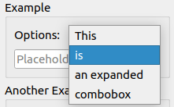

Expanded QCombobox

### Display Features

A QComboBox is a compact way to present a list of options to the user.

A combobox is a selection widget that shows the current item, and pops up a list of selectable items when clicked. Comboboxes can contain pixmaps as well as strings if the insertItem() and setItemText() functions are suitably overloaded.

### Editing Features

A combobox may be editable, allowing the user to modify each item in the list. For editable comboboxes, the function clearEditText() is provided, to clear the displayed string without changing the combobox's contents.

When the user enters a new string in an editable combobox, the widget may or may not insert it, and it can insert it in several locations. The default policy is InsertAtBottom but you can change this using setInsertPolicy().

It is possible to constrain the input to an editable combobox using QValidator; see setValidator(). By default, any input is accepted.

A combobox can be populated using the insert functions, insertItem() and insertItems() for example. Items can be changed with setItemText(). An item can be removed with removeItem() and all items can be removed with clear(). The text of the current item is returned by currentText(), and the text of a numbered item is returned with text(). The current item can be set with setCurrentIndex(). The number of items in the combobox is returned by count(); the maximum number of items can be set with setMaxCount(). You can allow editing using setEditable(). For editable comboboxes you can set auto-completion using setCompleter() and whether or not the user can add duplicates is set with setDuplicatesEnabled().

### Signals

There are three signals emitted if the current item of a combobox changes: currentIndexChanged(), currentTextChanged(), and activated(). currentIndexChanged() and currentTextChanged() are always emitted regardless if the change was done programmatically or by user interaction, while activated() is only emitted when the change is caused by user interaction. The highlighted() signal is emitted when the user highlights an item in the combobox popup list. All three signals exist in two versions, one with a QString argument and one with an `int` argument. If the user selects or highlights a pixmap, only the `int` signals are emitted. Whenever the text of an editable combobox is changed, the editTextChanged() signal is emitted.

### Model/View Framework

QComboBox uses the model/view framework for its popup list and to store its items. By default a QStandardItemModel stores the items and a QListView subclass displays the popuplist. You can access the model and view directly (with model() and view()), but QComboBox also provides functions to set and get item data, for example, setItemData() and itemText(). You can also set a new model and view (with setModel() and setView()). For the text and icon in the combobox label, the data in the model that has the Qt::DisplayRole and Qt::DecorationRole is used.

**Note:** You cannot alter the SelectionMode of the view(), for example, by using setSelectionMode().

**See also** QLineEdit, QSpinBox, QRadioButton, and QButtonGroup.

## Member Type Documentation

### enum QComboBox::InsertPolicy

This enum specifies what the QComboBox should do when a new string is entered by the user.

| Constant | Value | Description |
| --- | --- | --- |
| `QComboBox::NoInsert` | `0` | The string will not be inserted into the combobox. |
| `QComboBox::InsertAtTop` | `1` | The string will be inserted as the first item in the combobox. |
| `QComboBox::InsertAtCurrent` | `2` | The current item will be *replaced* by the string. |
| `QComboBox::InsertAtBottom` | `3` | The string will be inserted after the last item in the combobox. |
| `QComboBox::InsertAfterCurrent` | `4` | The string is inserted after the current item in the combobox. |
| `QComboBox::InsertBeforeCurrent` | `5` | The string is inserted before the current item in the combobox. |
| `QComboBox::InsertAlphabetically` | `6` | The string is inserted in the alphabetic order in the combobox. |

### `[since 6.9]` enum class QComboBox::LabelDrawingMode

This enum specifies how the combobox draws its label.

| Constant | Value | Description |
| --- | --- | --- |
| `QComboBox::LabelDrawingMode::UseStyle` | `0` | The combobox uses the style to draw its label. |
| `QComboBox::LabelDrawingMode::UseDelegate` | `1` | The combobox uses the item delegate to draw the label. Set a suitable item delegate when using this mode. |

This enum was introduced in Qt 6.9.

**See also** labelDrawingMode and [Books example](https://doc.qt.io/qt-6.9/qtsql-books-example.html).

### enum QComboBox::SizeAdjustPolicy

This enum specifies how the size hint of the QComboBox should adjust when new content is added or content changes.

| Constant | Value | Description |
| --- | --- | --- |
| `QComboBox::AdjustToContents` | `0` | The combobox will always adjust to the contents |
| `QComboBox::AdjustToContentsOnFirstShow` | `1` | The combobox will adjust to its contents the first time it is shown. |
| `QComboBox::AdjustToMinimumContentsLengthWithIcon` | `2` | The combobox will adjust to minimumContentsLength plus space for an icon. For performance reasons use this policy on large models. |

## Property Documentation

### `[read-only]` count : const int

This property holds the number of items in the combobox.

By default, for an empty combo box, this property has a value of 0.

**Access functions:**

| int | **count**() const |
| --- | --- |

### `[read-only]` currentData : const QVariant

This property holds the data for the current item

By default, for an empty combo box or a combo box in which no current item is set, this property contains an invalid QVariant.

**Access functions:**

| QVariant | **currentData**(int *role* = Qt::UserRole) const |
| --- | --- |

### currentIndex : int

This property holds the index of the current item in the combobox.

The current index can change when inserting or removing items.

By default, for an empty combo box or a combo box in which no current item is set, this property has a value of -1.

**Access functions:**

| int | **currentIndex**() const |
| --- | --- |
| void | **setCurrentIndex**(int *index*) |

**Notifier signal:**

| void | **currentIndexChanged**(int *index*) |
| --- | --- |

### currentText : QString

This property holds the current text

If the combo box is editable, the current text is the value displayed by the line edit. Otherwise, it is the value of the current item or an empty string if the combo box is empty or no current item is set.

The setter setCurrentText() simply calls setEditText() if the combo box is editable. Otherwise, if there is a matching text in the list, currentIndex is set to the corresponding index.

**Access functions:**

| QString | **currentText**() const |
| --- | --- |
| void | **setCurrentText**(const QString &*text*) |

**Notifier signal:**

| void | **currentTextChanged**(const QString &*text*) |
| --- | --- |

**See also** editable and setEditText().

### duplicatesEnabled : bool

This property holds whether the user can enter duplicate items into the combobox.

Note that it is always possible to programmatically insert duplicate items into the combobox.

By default, this property is `false` (duplicates are not allowed).

**Access functions:**

| bool | **duplicatesEnabled**() const |
| --- | --- |
| void | **setDuplicatesEnabled**(bool *enable*) |

### editable : bool

This property holds whether the combo box can be edited by the user.

By default, this property is `false`. The effect of editing depends on the insert policy.

**Note:** When disabling the *editable* state, the validator and completer are removed.

**Access functions:**

| bool | **isEditable**() const |
| --- | --- |
| void | **setEditable**(bool *editable*) |

**See also** InsertPolicy.

### frame : bool

This property holds whether the combo box draws itself with a frame.

If enabled (the default) the combo box draws itself inside a frame, otherwise the combo box draws itself without any frame.

**Access functions:**

| bool | **hasFrame**() const |
| --- | --- |
| void | **setFrame**(bool) |

### iconSize : QSize

This property holds the size of the icons shown in the combobox.

Unless explicitly set this returns the default value of the current style. This size is the maximum size that icons can have; icons of smaller size are not scaled up.

**Access functions:**

| QSize | **iconSize**() const |
| --- | --- |
| void | **setIconSize**(const QSize &*size*) |

### insertPolicy : InsertPolicy

This property holds the policy used to determine where user-inserted items should appear in the combobox.

The default value is InsertAtBottom, indicating that new items will appear at the bottom of the list of items.

**Access functions:**

| QComboBox::InsertPolicy | **insertPolicy**() const |
| --- | --- |
| void | **setInsertPolicy**(QComboBox::InsertPolicy *policy*) |

**See also** InsertPolicy.

### `[since 6.9]` labelDrawingMode : LabelDrawingMode

This property holds the mode used by the combobox to draw its label.

The default value is UseStyle. When changing this property to UseDelegate, make sure to also set a suitable item delegate. The default delegate depends on the style and might not be suitable for drawing the label.

This property was introduced in Qt 6.9.

**Access functions:**

| QComboBox::LabelDrawingMode | **labelDrawingMode**() const |
| --- | --- |
| void | **setLabelDrawingMode**(QComboBox::LabelDrawingMode *labelDrawing*) |

**See also** [Books example](https://doc.qt.io/qt-6.9/qtsql-books-example.html).

### maxCount : int

This property holds the maximum number of items allowed in the combobox.

**Note:** If you set the maximum number to be less then the current amount of items in the combobox, the extra items will be truncated. This also applies if you have set an external model on the combobox.

By default, this property's value is derived from the highest signed integer available (typically 2147483647).

**Access functions:**

| int | **maxCount**() const |
| --- | --- |
| void | **setMaxCount**(int *max*) |

### maxVisibleItems : int

This property holds the maximum allowed size on screen of the combo box, measured in items

By default, this property has a value of 10.

**Note:** This property is ignored for non-editable comboboxes in styles that returns true for QStyle::SH_ComboBox_Popup such as the Mac style or the Gtk+ Style.

**Access functions:**

| int | **maxVisibleItems**() const |
| --- | --- |
| void | **setMaxVisibleItems**(int *maxItems*) |

### minimumContentsLength : int

This property holds the minimum number of characters that should fit into the combobox.

The default value is 0.

If this property is set to a positive value, the minimumSizeHint() and sizeHint() take it into account.

**Access functions:**

| int | **minimumContentsLength**() const |
| --- | --- |
| void | **setMinimumContentsLength**(int *characters*) |

**See also** sizeAdjustPolicy.

### modelColumn : int

This property holds the column in the model that is visible.

If set prior to populating the combo box, the pop-up view will not be affected and will show the first column (using this property's default value).

By default, this property has a value of 0.

**Note:** In an editable combobox, the visible column will also become the completion column.

**Access functions:**

| int | **modelColumn**() const |
| --- | --- |
| void | **setModelColumn**(int *visibleColumn*) |

### placeholderText : QString

Sets a *placeholderText* text shown when no valid index is set.

The *placeholderText* will be shown when an invalid index is set. The text is not accessible in the dropdown list. When this function is called before items are added the placeholder text will be shown, otherwise you have to call setCurrentIndex(-1) programmatically if you want to show the placeholder text. Set an empty placeholder text to reset the setting.

When the QComboBox is editable, use QLineEdit::setPlaceholderText() instead.

**Access functions:**

| QString | **placeholderText**() const |
| --- | --- |
| void | **setPlaceholderText**(const QString &*placeholderText*) |

### sizeAdjustPolicy : SizeAdjustPolicy

This property holds the policy describing how the size of the combobox changes when the content changes.

The default value is AdjustToContentsOnFirstShow.

**Access functions:**

| QComboBox::SizeAdjustPolicy | **sizeAdjustPolicy**() const |
| --- | --- |
| void | **setSizeAdjustPolicy**(QComboBox::SizeAdjustPolicy *policy*) |

**See also** SizeAdjustPolicy.

## Member Function Documentation

### `[explicit]` QComboBox::QComboBox(QWidget **parent* = nullptr)

Constructs a combobox with the given *parent*, using the default model QStandardItemModel.

### `[virtual noexcept]` QComboBox::~QComboBox()

Destroys the combobox.

### `[signal]` void QComboBox::activated(int *index*)

This signal is sent when the user chooses an item in the combobox. The item's *index* is passed. Note that this signal is sent even when the choice is not changed. If you need to know when the choice actually changes, use signal currentIndexChanged() or currentTextChanged().

### void QComboBox::addItem(const QString &*text*, const QVariant &*userData* = QVariant())

Adds an item to the combobox with the given *text*, and containing the specified *userData* (stored in the Qt::UserRole). The item is appended to the list of existing items.

### void QComboBox::addItem(const QIcon &*icon*, const QString &*text*, const QVariant &*userData* = QVariant())

Adds an item to the combobox with the given *icon* and *text*, and containing the specified *userData* (stored in the Qt::UserRole). The item is appended to the list of existing items.

### void QComboBox::addItems(const QStringList &*texts*)

Adds each of the strings in the given *texts* to the combobox. Each item is appended to the list of existing items in turn.

### `[override virtual protected]` void QComboBox::changeEvent(QEvent **e*)

Reimplements: QWidget::changeEvent(QEvent *event).

### `[slot]` void QComboBox::clear()

Clears the combobox, removing all items.

Note: If you have set an external model on the combobox this model will still be cleared when calling this function.

### `[slot]` void QComboBox::clearEditText()

Clears the contents of the line edit used for editing in the combobox.

### QCompleter *QComboBox::completer() const

Returns the completer that is used to auto complete text input for the combobox.

**See also** setCompleter() and editable.

### `[override virtual protected]` void QComboBox::contextMenuEvent(QContextMenuEvent **e*)

Reimplements: QWidget::contextMenuEvent(QContextMenuEvent *event).

### `[signal]` void QComboBox::currentIndexChanged(int *index*)

This signal is sent whenever the currentIndex in the combobox changes either through user interaction or programmatically. The item's *index* is passed or -1 if the combobox becomes empty or the currentIndex was reset.

**Note:** Notifier signal for property currentIndex.

### `[signal]` void QComboBox::currentTextChanged(const QString &*text*)

This signal is emitted whenever currentText changes. The new value is passed as *text*.

**Note:** It is not emitted, if currentText remains the same, even if currentIndex changes.

**Note:** Notifier signal for property currentText.

### `[signal]` void QComboBox::editTextChanged(const QString &*text*)

This signal is emitted when the text in the combobox's line edit widget is changed. The new text is specified by *text*.

### `[override virtual]` bool QComboBox::event(QEvent **event*)

Reimplements: QWidget::event(QEvent *event).

### int QComboBox::findData(const QVariant &*data*, int *role* = Qt::UserRole, Qt::MatchFlags *flags* = static_cast<Qt::MatchFlags>(Qt::MatchExactly|Qt::MatchCaseSensitive)) const

Returns the index of the item containing the given *data* for the given *role*; otherwise returns -1.

The *flags* specify how the items in the combobox are searched.

### int QComboBox::findText(const QString &*text*, Qt::MatchFlags *flags* = Qt::MatchExactly|Qt::MatchCaseSensitive) const

Returns the index of the item containing the given *text*; otherwise returns -1.

The *flags* specify how the items in the combobox are searched.

### `[override virtual protected]` void QComboBox::focusInEvent(QFocusEvent **e*)

Reimplements: QWidget::focusInEvent(QFocusEvent *event).

### `[override virtual protected]` void QComboBox::focusOutEvent(QFocusEvent **e*)

Reimplements: QWidget::focusOutEvent(QFocusEvent *event).

### `[override virtual protected]` void QComboBox::hideEvent(QHideEvent **e*)

Reimplements: QWidget::hideEvent(QHideEvent *event).

### `[virtual]` void QComboBox::hidePopup()

Hides the list of items in the combobox if it is currently visible and resets the internal state, so that if the custom pop-up was shown inside the reimplemented showPopup(), then you also need to reimplement the hidePopup() function to hide your custom pop-up and call the base class implementation to reset the internal state whenever your custom pop-up widget is hidden.

**See also** showPopup().

### `[signal]` void QComboBox::highlighted(int *index*)

This signal is sent when an item in the combobox popup list is highlighted by the user. The item's *index* is passed.

### `[virtual protected]` void QComboBox::initStyleOption(QStyleOptionComboBox **option*) const

Initialize *option* with the values from this QComboBox. This method is useful for subclasses when they need a QStyleOptionComboBox, but don't want to fill in all the information themselves.

**See also** QStyleOption::initFrom().

### `[override virtual protected]` void QComboBox::inputMethodEvent(QInputMethodEvent **e*)

Reimplements: QWidget::inputMethodEvent(QInputMethodEvent *event).

### `[override virtual]` QVariant QComboBox::inputMethodQuery(Qt::InputMethodQuery *query*) const

Reimplements: QWidget::inputMethodQuery(Qt::InputMethodQuery query) const.

### void QComboBox::insertItem(int *index*, const QString &*text*, const QVariant &*userData* = QVariant())

Inserts the *text* and *userData* (stored in the Qt::UserRole) into the combobox at the given *index*.

If the index is equal to or higher than the total number of items, the new item is appended to the list of existing items. If the index is zero or negative, the new item is prepended to the list of existing items.

**See also** insertItems().

### void QComboBox::insertItem(int *index*, const QIcon &*icon*, const QString &*text*, const QVariant &*userData* = QVariant())

Inserts the *icon*, *text* and *userData* (stored in the Qt::UserRole) into the combobox at the given *index*.

If the index is equal to or higher than the total number of items, the new item is appended to the list of existing items. If the index is zero or negative, the new item is prepended to the list of existing items.

**See also** insertItems().

### void QComboBox::insertItems(int *index*, const QStringList &*list*)

Inserts the strings from the *list* into the combobox as separate items, starting at the *index* specified.

If the index is equal to or higher than the total number of items, the new items are appended to the list of existing items. If the index is zero or negative, the new items are prepended to the list of existing items.

**See also** insertItem().

### void QComboBox::insertSeparator(int *index*)

Inserts a separator item into the combobox at the given *index*.

If the index is equal to or higher than the total number of items, the new item is appended to the list of existing items. If the index is zero or negative, the new item is prepended to the list of existing items.

**See also** insertItem().

### QVariant QComboBox::itemData(int *index*, int *role* = Qt::UserRole) const

Returns the data for the given *role* in the given *index* in the combobox, or an invalid QVariant if there is no data for this role.

**See also** setItemData().

### QAbstractItemDelegate *QComboBox::itemDelegate() const

Returns the item delegate used by the popup list view.

**See also** setItemDelegate().

### QIcon QComboBox::itemIcon(int *index*) const

Returns the icon for the given *index* in the combobox.

**See also** setItemIcon().

### QString QComboBox::itemText(int *index*) const

Returns the text for the given *index* in the combobox.

**See also** setItemText().

### `[override virtual protected]` void QComboBox::keyPressEvent(QKeyEvent **e*)

Reimplements: QWidget::keyPressEvent(QKeyEvent *event).

### `[override virtual protected]` void QComboBox::keyReleaseEvent(QKeyEvent **e*)

Reimplements: QWidget::keyReleaseEvent(QKeyEvent *event).

### QLineEdit *QComboBox::lineEdit() const

Returns the line edit used to edit items in the combobox, or `nullptr` if there is no line edit.

Only editable combo boxes have a line edit.

**See also** setLineEdit().

### `[override virtual]` QSize QComboBox::minimumSizeHint() const

Reimplements an access function for property: QWidget::minimumSizeHint.

### QAbstractItemModel *QComboBox::model() const

Returns the model used by the combobox.

**See also** setModel().

### `[override virtual protected]` void QComboBox::mousePressEvent(QMouseEvent **e*)

Reimplements: QWidget::mousePressEvent(QMouseEvent *event).

### `[override virtual protected]` void QComboBox::mouseReleaseEvent(QMouseEvent **e*)

Reimplements: QWidget::mouseReleaseEvent(QMouseEvent *event).

### `[override virtual protected]` void QComboBox::paintEvent(QPaintEvent **e*)

Reimplements: QWidget::paintEvent(QPaintEvent *event).

### void QComboBox::removeItem(int *index*)

Removes the item at the given *index* from the combobox. This will update the current index if the index is removed.

This function does nothing if *index* is out of range.

### `[override virtual protected]` void QComboBox::resizeEvent(QResizeEvent **e*)

Reimplements: QWidget::resizeEvent(QResizeEvent *event).

### QModelIndex QComboBox::rootModelIndex() const

Returns the root model item index for the items in the combobox.

**See also** setRootModelIndex().

### void QComboBox::setCompleter(QCompleter **completer*)

Sets the *completer* to use instead of the current completer. If *completer* is `nullptr`, auto completion is disabled.

By default, for an editable combo box, a QCompleter that performs case insensitive inline completion is automatically created.

**Note:** The completer is removed when the editable property becomes `false`, or when the line edit is replaced by a call to setLineEdit(). Setting a completer on a QComboBox that is not editable will be ignored.

**See also** completer().

### `[slot]` void QComboBox::setEditText(const QString &*text*)

Sets the *text* in the combobox's text edit.

### void QComboBox::setItemData(int *index*, const QVariant &*value*, int *role* = Qt::UserRole)

Sets the data *role* for the item on the given *index* in the combobox to the specified *value*.

**See also** itemData().

### void QComboBox::setItemDelegate(QAbstractItemDelegate **delegate*)

Sets the item *delegate* for the popup list view. The combobox takes ownership of the delegate.

Any existing delegate will be removed, but not deleted. QComboBox does not take ownership of *delegate*.

**Warning:** You should not share the same instance of a delegate between comboboxes, widget mappers or views. Doing so can cause incorrect or unintuitive editing behavior since each view connected to a given delegate may receive the closeEditor() signal, and attempt to access, modify or close an editor that has already been closed.

**See also** itemDelegate().

### void QComboBox::setItemIcon(int *index*, const QIcon &*icon*)

Sets the *icon* for the item on the given *index* in the combobox.

**See also** itemIcon().

### void QComboBox::setItemText(int *index*, const QString &*text*)

Sets the *text* for the item on the given *index* in the combobox.

**See also** itemText().

### void QComboBox::setLineEdit(QLineEdit **edit*)

Sets the line *edit* to use instead of the current line edit widget.

The combo box takes ownership of the line edit.

**Note:** Since the combobox's line edit owns the QCompleter, any previous call to setCompleter() will no longer have any effect.

**See also** lineEdit().

### `[virtual]` void QComboBox::setModel(QAbstractItemModel **model*)

Sets the model to be *model*. *model* must not be `nullptr`. If you want to clear the contents of a model, call clear().

**Note:** If the combobox is editable, then the *model* will also be set on the completer of the line edit.

**See also** model(), clear(), and setCompleter().

### void QComboBox::setRootModelIndex(const QModelIndex &*index*)

Sets the root model item *index* for the items in the combobox.

**See also** rootModelIndex().

### void QComboBox::setValidator(const QValidator **validator*)

Sets the *validator* to use instead of the current validator.

**Note:** The validator is removed when the editable property becomes `false`.

**See also** validator().

### void QComboBox::setView(QAbstractItemView **itemView*)

Sets the view to be used in the combobox popup to the given *itemView*. The combobox takes ownership of the view.

Note: If you want to use the convenience views (like QListWidget, QTableWidget or QTreeWidget), make sure to call setModel() on the combobox with the convenience widgets model before calling this function.

**See also** view().

### `[override virtual protected]` void QComboBox::showEvent(QShowEvent **e*)

Reimplements: QWidget::showEvent(QShowEvent *event).

### `[virtual]` void QComboBox::showPopup()

Displays the list of items in the combobox. If the list is empty then no items will be shown.

If you reimplement this function to show a custom pop-up, make sure you call hidePopup() to reset the internal state.

**See also** hidePopup().

### `[override virtual]` QSize QComboBox::sizeHint() const

Reimplements an access function for property: QWidget::sizeHint.

This implementation caches the size hint to avoid resizing when the contents change dynamically. To invalidate the cached value change the sizeAdjustPolicy.

### `[signal]` void QComboBox::textActivated(const QString &*text*)

This signal is sent when the user chooses an item in the combobox. The item's *text* is passed. Note that this signal is sent even when the choice is not changed. If you need to know when the choice actually changes, use signal currentIndexChanged() or currentTextChanged().

### `[signal]` void QComboBox::textHighlighted(const QString &*text*)

This signal is sent when an item in the combobox popup list is highlighted by the user. The item's *text* is passed.

### const QValidator *QComboBox::validator() const

Returns the validator that is used to constrain text input for the combobox.

**See also** setValidator() and editable.

### QAbstractItemView *QComboBox::view() const

Returns the list view used for the combobox popup.

**See also** setView().

### `[override virtual protected]` void QComboBox::wheelEvent(QWheelEvent **e*)

Reimplements: QWidget::wheelEvent(QWheelEvent *event).

© The Qt Company Ltd  
Licensed under the GNU Free Documentation License, Version 1.3.  
https://doc.qt.io/qt-6.9/qcombobox.html